# R Notebook

Minature performes dimensionality reduction on a low-resolution representation of a highly multiplexed imaging dataset in order to provide a thumbnail that represents the spatial heterogenity in the dataset.

Points are coloured by translating their position in 3D low dimension space to a LAB colour. As this is broadly perceptually uniform, similar colours will be closely localised in low-dimension space and therefore have a more similar marker expression signature.

Minature requires:

```r
library(EBImage)
library(tidyverse)
library(scales)
library(dynutils)
library(colorspace)
library(uwot)
```

```r
test_paths <- list.files(here::here("data"), full.names = TRUE)
```

```r
source('~/miniature/R/paint_minaiture.R')
```

Default settings output to a tempfile, the path of which is returned

Future versions should look to pull a set level of the image pyramid Note that exact colours and embedding may vary with runs as `fast_sgd` has been set to `TRUE` in `uwot::umap` which accelerates embedding at the cost of exact reproducibility.

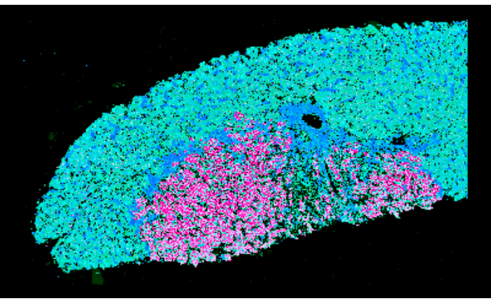

Mapping accros several examples with default settings

```r
tibble(input = test_paths) %>%
  mutate(
    outputs = basename(input) %>% paste0("~/miniature/outputs/",.) %>% str_remove(".ome.tif*") %>% paste0(.,"-miniature.png"),
    painting = map2(input, outputs, paint_miniature)
  )
```

```
[1] "Reading image: /home/ubuntu/miniature/data/HT060P1_REMAIN_ROI_04.ome.tiff"
[1] "Resizing image to 512 px in largest dimension"
[1] "Making datacube"
[1] "Finding background with Otsu's threshold"
[1] "Preparation complete!"
[1] "Starting dimensionality reduction"
```

```
[1] "Dimensionality reduction complete"
[1] "Generating colours"
[1] "Painting miniature"
[1] "Saving miniature to ~/miniature/outputs/HT060P1_REMAIN_ROI_04-miniature.png"
[1] "Reading image: /home/ubuntu/miniature/data/HTA9_1_BA_L_ROI04.ome.tif"
[1] "Resizing image to 512 px in largest dimension"
[1] "Making datacube"
[1] "Finding background with Otsu's threshold"
[1] "Preparation complete!"
[1] "Starting dimensionality reduction"
```

```
[1] "Dimensionality reduction complete"
[1] "Generating colours"
[1] "Painting miniature"
[1] "Saving miniature to ~/miniature/outputs/HTA9_1_BA_L_ROI04-miniature.png"
[1] "Reading image: /home/ubuntu/miniature/data/HTA9_1_BA_M_ROI03.ome.tif"
[1] "Resizing image to 512 px in largest dimension"
[1] "Making datacube"
[1] "Finding background with Otsu's threshold"
[1] "Preparation complete!"
[1] "Starting dimensionality reduction"
```

```
[1] "Dimensionality reduction complete"
[1] "Generating colours"
[1] "Painting miniature"
[1] "Saving miniature to ~/miniature/outputs/HTA9_1_BA_M_ROI03-miniature.png"
[1] "Reading image: /home/ubuntu/miniature/data/HTA9_1_POST_M_ROI02.ome.tif"
[1] "Resizing image to 512 px in largest dimension"
[1] "Making datacube"
[1] "Finding background with Otsu's threshold"
[1] "Preparation complete!"
[1] "Starting dimensionality reduction"
```

```
[1] "Dimensionality reduction complete"
[1] "Generating colours"
[1] "Painting miniature"
[1] "Saving miniature to ~/miniature/outputs/HTA9_1_POST_M_ROI02-miniature.png"
```

| input | outputs | painting |
| --- | --- | --- |
| /home/ubuntu/miniature/data/HT060P1_REMAIN_ROI_04.ome.tiff | ~/miniature/outputs/HT060P1_REMAIN_ROI_04-miniature.png |  |
| /home/ubuntu/miniature/data/HTA9_1_BA_L_ROI04.ome.tif | ~/miniature/outputs/HTA9_1_BA_L_ROI04-miniature.png |  |
| /home/ubuntu/miniature/data/HTA9_1_BA_M_ROI03.ome.tif | ~/miniature/outputs/HTA9_1_BA_M_ROI03-miniature.png |  |
| /home/ubuntu/miniature/data/HTA9_1_POST_M_ROI02.ome.tif | ~/miniature/outputs/HTA9_1_POST_M_ROI02-miniature.png |  |

Displaying these examples

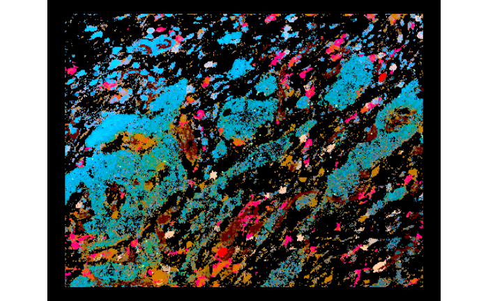

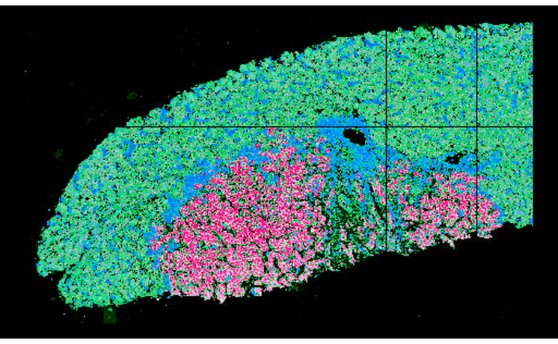

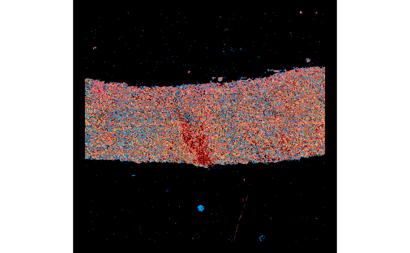

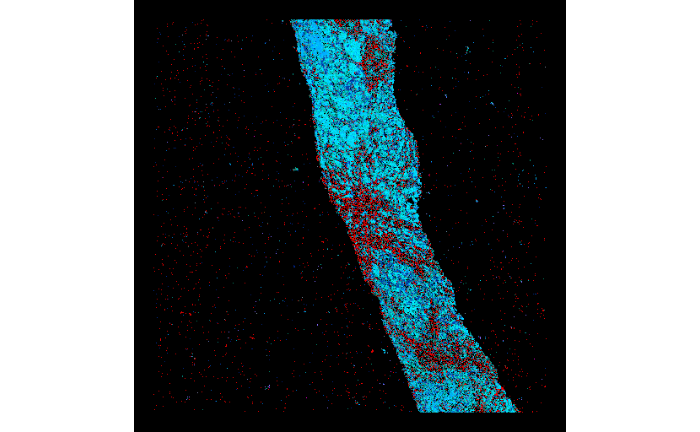

```r
tibble(input = test_paths) %>%
  mutate(
    outputs = basename(input) %>% paste0("~/miniature/outputs/",.) %>% str_remove(".ome.tif*") %>% paste0(.,"-miniature.png"),
    images = map(outputs, readImage)
  ) %>%
  pull(images) %>%
  map(display, method = "raster")
```

## Getting low dimensional embedding for further plotting

Setting `return_objects == TRUE` returns the processed data to enable further visualisation of the low dimension space

```r
miniature_objects <- paint_miniature(
  test_paths[2],
  return_objects = TRUE,
  output_max_dim = 300
  )
```

```
[1] "Reading image: /home/ubuntu/miniature/data/HTA9_1_BA_L_ROI04.ome.tif"
[1] "Resizing image to 300 px in largest dimension"
[1] "Making datacube"
[1] "Finding background with Otsu's threshold"
[1] "Preparation complete!"
[1] "Starting dimensionality reduction"
```

```
11:22:03 2258 smooth knn distance failures
```

```
[1] "Dimensionality reduction complete"
[1] "Generating colours"
```

```
The `x` argument of `as_tibble.matrix()` must have unique column names if `.name_repair` is omitted as of tibble 2.0.0.
Using compatibility `.name_repair`.
```

```
[1] "Painting miniature"
[1] "Saving miniature to /tmp/RtmpKpiosh/fileb193be5861b.png"
```

Plot the image and embedding in low-dimension space (3D embedding, Dim1 and Dim2 shown)

[figure not shown]

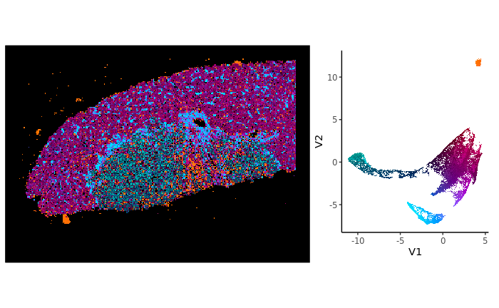

## Background removal

By default `paint_miniature` attempts background removal using Otsu’s threshold on the log scaled channel sum image This can be acccessed through the small_image slot

```r
miniature_objects$small_image$otsu_image %>% display(method = "raster")
```

[output not shown]

Background subtraction can be turned off by setting `remove_bg` as FALSE

```r
bg_retained <- paint_miniature(
  test_paths[2],
  remove_bg = FALSE,
  output_max_dim = 300
  ) %>%
  readImage() %>%
  display(method = "raster")
```

[output not shown]